# Vowel Artic in PD: Bayesian Analysis

# Packages

```r
library(tidyverse)
library(ggrepel)
library(extraDistr) # install.packages("extraDistr")
library(HDInterval) # install.packages("HDInterval")
library(tidybayes) # install.packages("tidybayes")
library(bayesplot) # install.packages("bayesplot")
library(modelr)
library(broom.mixed) # install.packages("broom.mixed")
library(brms) # install.packages("brms")
theme_set(theme_minimal())
```

# Background

This study is a follow-up analysis of our previous work examining the predictive value of acoustic and kinematic measures in predicting intelligibility and articulatory precision in speakers with and without Parkinson’s disease (PD; https://osf.io/hfuq5/).

Our previous findings indicated that among several measures, vowel space area (VSA), and kinematic distance were the best predictors of both intelligibility and articulatory precision. However, this relationship was examined using pooled data, without considering differences in speaking group (control vs. PD) or condition (conversational vs. more clear). Therefore, it remains unknown how speakers with and without dysarthria due to PD differ in terms of intelligibility, articulatory precision, VSA, and kinematic distance. Additionally, it is unclear how these groups respond to prompts to speak more clearly. Thus, the following research questions were posed:

1. How do speakers with and without PD of varying dysarthria severity levels differ in terms of intelligibility, articulatory precision, vowel space area (VSA), and kinematic distance? (Group Effects)
2. When prompted to speak more clearly, how do speakers with and without PD of varying dysarthria severities modify their articulation (VSA and kinematic distance), and does this cue result in perceptual gains in intelligibility and articulatory precision? (Group × Condition Interaction Effects)

# Data Analysis

Before we can build our models, we’ll need some information about the speakers.

```r
speakerList <-
  rio::import(file = "../Data/PreppedData/Speaker List_Clean.csv") %>%
  dplyr::select(!`Folder 2`:`Sentence Repetition`) %>%

  # Making sure dxTime is numeric
  dplyr::mutate(dxTime = as.numeric(dxTime)) %>%

  # Refactoring Sex
  dplyr::mutate(Sex = factor(
    Sex,
    levels = c("M",
               "F"),
    labels = c("Male Speakers",
               "Female Speakers")
  )) %>%

  # Removing the MoCA Scores - Not all speakers had them
  dplyr::select(!MoCA)
```

## Intelligibility

Intelligibility was collected through ratings obtained through a listener survey. They would listen to a speaker, and then rate how intelligible the speaker was using a horizontally oriented visual analog scale. The left end of the scale was labeled “Cannot understand anything” and corresponded to a value of 0. The right end of the scale was labeled “Understood everything” and corresponded to a value of 100.

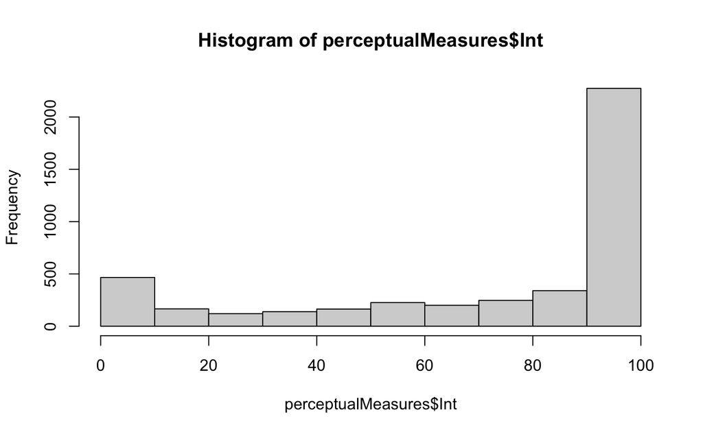

```r
perceptualMeasures <- rio::import(file = "../Data/PreppedData/ListenerData/ListenerRatings_allRatings.csv") %>%
  dplyr::select(!V1) %>%
  dplyr::filter(ratingType == "Int") %>% # We only want the intelligibility ratings for this model
  dplyr::filter(condition != "lessClear") %>% # We won't use the less clear condition in this study

  # Here we rename some variables and clean up the factors
  dplyr::rename(Int = Rating) %>%
  dplyr::mutate(Sex = factor(Sex, levels = c("M", "F")),
                condition = factor(condition, levels = c("conv", "moreClear"))) %>%

  # Now we merge the intelligibility ratings with the speakerList, which has information about severity level.
  base::merge(., speakerList %>%
                dplyr::select(StudyID, Severity)) %>%
  dplyr::mutate(
    Severity = factor(
      Severity,
      levels = c("HC", "Mild", "Moderate", "Severe", "Profound"),
      labels = c("Control", "Mild", "Moderate", "Severe", "Profound")
    )
  )

# Lets visualize the outcome measure, intelligibility
hist(perceptualMeasures$Int)
```

```r
# Here, we rescale the measure to fit a beta distribtion
epsilon <- 1e-5
modelData <- perceptualMeasures %>%
  dplyr::select(StudyID,
                Group,
                Sex,
                Age,
                Severity,
                condition,
                Sent,
                rep,
                ListenerID,
                Int) %>%
  dplyr::mutate(
    Int = Int / 100,
    # the following makes sure that 0 and 1 are not included in the beta distribution
    Int = Int * ((nrow(.) - 1) + .5) / nrow(.),
    Int = Int * (1 - 2 * epsilon) + epsilon
  )

performance::check_distribution(modelData$Int)
```

```
# Predicted Distribution of Vector

  Distribution Probability
          beta         56%
     bernoulli         12%
 beta-binomial          9%
```

```r
# Taking out the trash
rm(perceptualMeasures, epsilon)
```

### Priors

First, we need to figure out the model parameters

```r
brms_Int_modelFormula <-
  Int ~ Severity * condition +
  (1 | StudyID / Sent / rep) + # Each Speaker (StudyID) read three sentences (Sent), five times each (rep)
  (1 | ListenerID)

brms::get_prior(
  brms_Int_modelFormula,
  data = modelData,
  family = Beta)
```

```
                prior     class                                coef            group resp
               (flat)         b
               (flat)         b                  conditionmoreClear
               (flat)         b                        SeverityMild
               (flat)         b     SeverityMild:conditionmoreClear
               (flat)         b                    SeverityModerate
               (flat)         b SeverityModerate:conditionmoreClear
               (flat)         b                    SeverityProfound
               (flat)         b SeverityProfound:conditionmoreClear
               (flat)         b                      SeveritySevere
               (flat)         b   SeveritySevere:conditionmoreClear
 student_t(3, 0, 2.5) Intercept
    gamma(0.01, 0.01)       phi
 student_t(3, 0, 2.5)        sd
 student_t(3, 0, 2.5)        sd                                           ListenerID
 student_t(3, 0, 2.5)        sd                           Intercept       ListenerID
 student_t(3, 0, 2.5)        sd                                              StudyID
 student_t(3, 0, 2.5)        sd                           Intercept          StudyID
 student_t(3, 0, 2.5)        sd                                         StudyID:Sent
 student_t(3, 0, 2.5)        sd                           Intercept     StudyID:Sent
 student_t(3, 0, 2.5)        sd                                     StudyID:Sent:rep
 student_t(3, 0, 2.5)        sd                           Intercept StudyID:Sent:rep
 dpar nlpar lb ub       source
                       default
                  (vectorized)
                  (vectorized)
                  (vectorized)
                  (vectorized)
                  (vectorized)
                  (vectorized)
                  (vectorized)
                  (vectorized)
                  (vectorized)
                       default
             0         default
             0         default
             0    (vectorized)
             0    (vectorized)
             0    (vectorized)
             0    (vectorized)
             0    (vectorized)
             0    (vectorized)
             0    (vectorized)
             0    (vectorized)
```

Now we can specify weakly informative priors.

```r
prior_int <- c(
  prior(normal(0, 10), class = Intercept), # start with larger value - 10
  prior(normal(0, 10), class = b),
  prior(cauchy(0, 10), class = sd), # paper on variance priors: https://projecteuclid.org/journals/bayesian-analysis/volume-1/issue-3/Prior-distributions-for-variance-parameters-in-hierarchical-models-comment-on/10.1214/06-BA117A.full - check 95% interval for cauchy - very large upper bound 10
  prior(gamma(1, 0.5), class = phi) # Phi = 1, mu = .5
)
```

### Building the model

```r
condition_int <- brms::brm(
  formula = brms_Int_modelFormula,
  data = modelData,
  prior = prior_int,
  family = Beta,
  chains = 4,
  cores = 4,
  iter = 4000,
  warmup = 1000,
  control = list(adapt_delta = 0.95),
  file = "Models/brms_Int.rds",
  file_refit = "on_change"
)
```

### Model Summary

```r
summary(condition_int)
```

```
 Family: beta
  Links: mu = logit; phi = identity
Formula: Int ~ Severity * condition + (1 | StudyID/Sent/rep) + (1 | ListenerID)
   Data: modelData (Number of observations: 4342)
  Draws: 4 chains, each with iter = 4000; warmup = 1000; thin = 1;
         total post-warmup draws = 12000

Multilevel Hyperparameters:
~ListenerID (Number of levels: 368)
              Estimate Est.Error l-95% CI u-95% CI Rhat Bulk_ESS Tail_ESS
sd(Intercept)     0.64      0.04     0.57     0.71 1.00     4610     7262

~StudyID (Number of levels: 40)
              Estimate Est.Error l-95% CI u-95% CI Rhat Bulk_ESS Tail_ESS
sd(Intercept)     0.39      0.07     0.26     0.54 1.00     4316     5774

~StudyID:Sent (Number of levels: 120)
              Estimate Est.Error l-95% CI u-95% CI Rhat Bulk_ESS Tail_ESS
sd(Intercept)     0.37      0.04     0.29     0.46 1.00     4948     7278

~StudyID:Sent:rep (Number of levels: 600)
              Estimate Est.Error l-95% CI u-95% CI Rhat Bulk_ESS Tail_ESS
sd(Intercept)     0.27      0.04     0.19     0.34 1.00     2614     5126

Regression Coefficients:
                                    Estimate Est.Error l-95% CI u-95% CI Rhat Bulk_ESS Tail_ESS
Intercept                               1.46      0.12     1.23     1.69 1.00     6105     8200
SeverityMild                            0.23      0.24    -0.23     0.72 1.00     8553     8015
SeverityModerate                       -0.29      0.24    -0.75     0.18 1.00     8357     9022
SeveritySevere                         -0.89      0.22    -1.32    -0.44 1.00     8329     8276
SeverityProfound                       -2.60      0.23    -3.04    -2.14 1.00     8012     8197
conditionmoreClear                      0.25      0.05     0.15     0.35 1.00    12314    10028
SeverityMild:conditionmoreClear        -0.08      0.11    -0.29     0.14 1.00    18377    10087
SeverityModerate:conditionmoreClear     0.03      0.11    -0.19     0.24 1.00    18480     9582
SeveritySevere:conditionmoreClear      -0.07      0.10    -0.27     0.13 1.00    17561     9876
SeverityProfound:conditionmoreClear     0.10      0.10    -0.10     0.30 1.00    17681     9750

Further Distributional Parameters:
    Estimate Est.Error l-95% CI u-95% CI Rhat Bulk_ESS Tail_ESS
phi     1.38      0.04     1.30     1.47 1.00     7149     7885

Draws were sampled using sampling(NUTS). For each parameter, Bulk_ESS
and Tail_ESS are effective sample size measures, and Rhat is the potential
scale reduction factor on split chains (at convergence, Rhat = 1).
```

### Model Diagnostics

[figure not shown]

[figure not shown]

[figure not shown]

[figure not shown]

```r
bayestestR::p_direction(condition_int)
```

```
Probability of Direction

Parameter                           |     pd
--------------------------------------------
(Intercept)                         |   100%
SeverityMild                        | 79.22%
SeverityModerate                    | 92.42%
SeveritySevere                      |   100%
SeverityProfound                    |   100%
conditionmoreClear                  |   100%
SeverityMild:conditionmoreClear     | 75.98%
SeverityModerate:conditionmoreClear | 61.36%
SeveritySevere:conditionmoreClear   | 72.93%
SeverityProfound:conditionmoreClear | 86.21%
```

### Visualizations

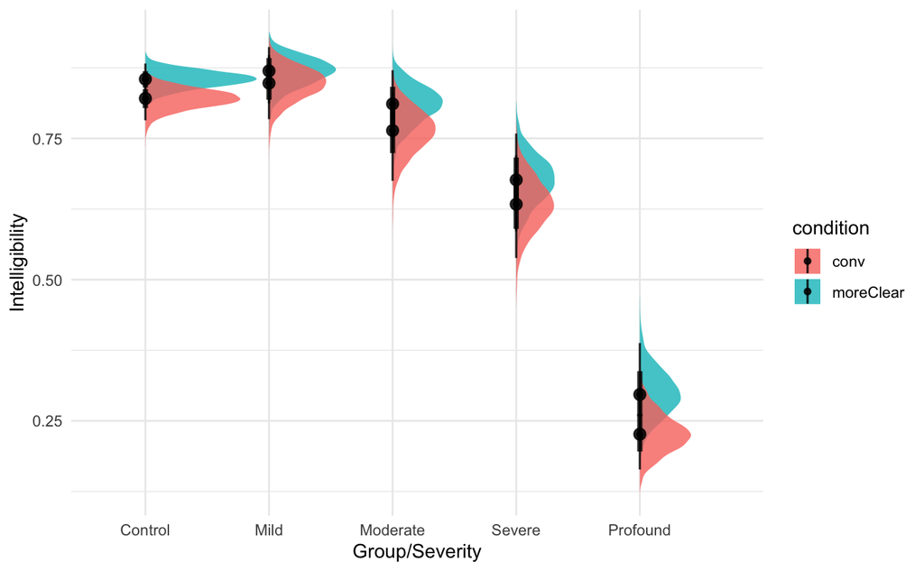

```r
epsilon <- 1e-5
post_Int_data <- modelData %>%
  data_grid(Severity, condition) %>%
  epred_draws(object = condition_int,
              ndraws = 4000,
              re_formula = NA) %>%
  # Reverse the transformation applied before running the model.
  dplyr::mutate(
    Int = (.epred - epsilon) / (1 - 2 * epsilon),
    # Step 1 & 2: Reverse the offset and scaling
    Int = Int * nrow(modelData) / ((nrow(modelData) - 1) + .5)
  )

post_Int_plot <- post_Int_data %>%
  ggplot() +
  aes(
    y = Int,
    x = Severity,
    group = condition,
    #alpha = condition,
    fill = condition
  ) +

  # Density + CrIs
  stat_halfeye(
    alpha = .8
  ) +

  # Rename axes
  labs(
    y = "Intelligibility",
    x = "Group/Severity"
  )
post_Int_plot
```

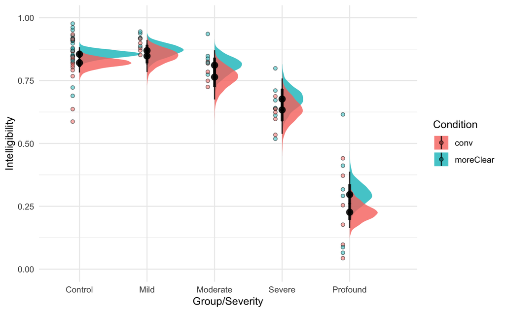

```r
int_agg <- modelData %>%
  # Reverse the transformation applied before running the model.
  dplyr::mutate(
    Int = (Int - epsilon) / (1 - 2 * epsilon),
    # Step 1 & 2: Reverse the offset and scaling
    Int = Int * nrow(modelData) / ((nrow(modelData) - 1) + .5)
  ) %>%
  group_by(StudyID, Severity, condition) %>%
  dplyr::summarise(.epred = mean(Int))
final_Int_plot <- post_Int_plot +
  geom_point(
    data = int_agg,
    aes(
      y = .epred,
      x = Severity,
      group = condition,
      fill = condition
    ),
    pch = 21,
    alpha = .5,
    position = position_nudge(x = -.1)
  ) +
  coord_cartesian(ylim = c(0, 1))  +
  labs(fill = "Condition")
final_Int_plot

ggsave(
  plot = final_Int_plot,
  filename = "Plots/brms_Int.png",
  height = 3,
  width = 5,
  units = "in",
  scale = 1,
  bg = "white"
)
```

## Articulatory Precision

Articulatory precision was collected in the same way as intelligibility ratings. They were collected through ratings obtained through a listener survey. They would listen to a speaker, and then rate how precise the speaker was using a horizontally oriented visual analog scale. The left end of the scale was labeled “imprecise or mumbled” and corresponded to a value of 0. The right end of the scale was labeled “precise or clear” and corresponded to a value of 100.

While any value between 0 and 100 could be selected, listeners tended to rate on the extreme ends, resulting in a beta distribution. Therefore, for this model, we used a beta family for our model. But first, we rescaled the precision ratings to fall between 0 and 1, excluding the endpoint values of 0 and 1.

### Loading the data

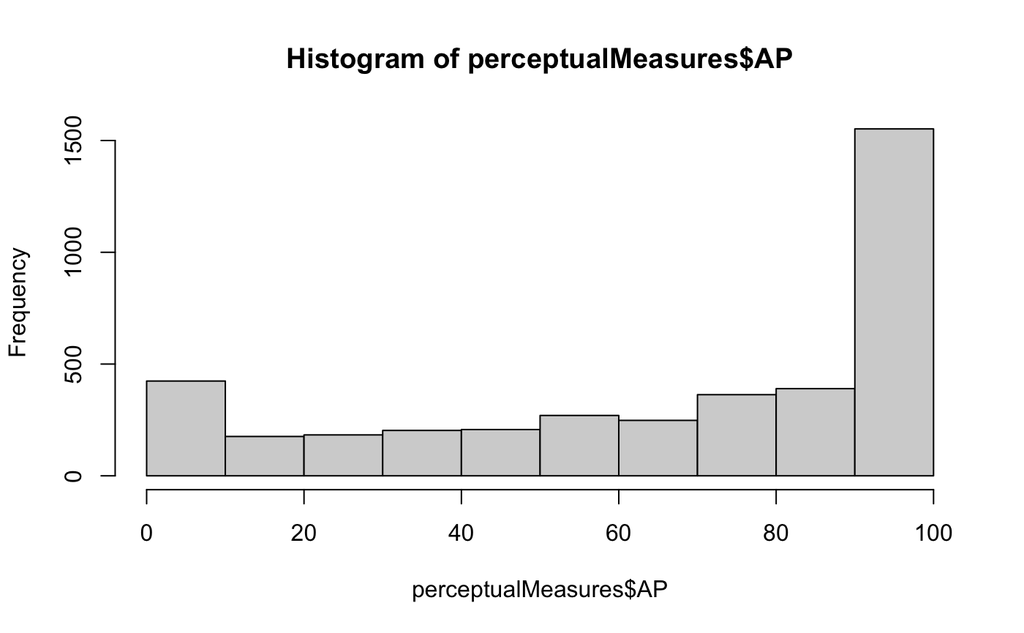

```r
perceptualMeasures <- rio::import(file = "../Data/PreppedData/ListenerData/ListenerRatings_allRatings.csv") %>%
  dplyr::select(!V1) %>%
  dplyr::filter(ratingType == "AP") %>% # We only want the articulatory precision ratings for this model
  dplyr::filter(condition != "lessClear") %>% # We won't use the less clear condition in this study

  # Here we rename some variables and clean up the factors
  dplyr::rename(AP = Rating) %>%
  dplyr::mutate(Sex = factor(Sex, levels = c("M", "F")),
                condition = factor(condition, levels = c("conv", "moreClear"))) %>%

  # Now we merge the AP ratings with the speakerList, which has information about severity level.
  base::merge(., speakerList %>%
                dplyr::select(StudyID, Severity)) %>%
  dplyr::mutate(
    Severity = factor(
      Severity,
      levels = c("HC", "Mild", "Moderate", "Severe", "Profound"),
      labels = c("Control", "Mild", "Moderate", "Severe", "Profound")
    )
  )


# Lets visualize the outcome measure, intelligibility
hist(perceptualMeasures$AP)
```

```r
# Here, we rescale the measure to fit a beta distribtion
epsilon <- 1e-5
modelData <- perceptualMeasures %>%
  dplyr::select(StudyID,
                Group,
                Sex,
                Age,
                Severity,
                condition,
                Sent,
                rep,
                ListenerID,
                AP) %>%
  dplyr::mutate(
    AP = AP / 100,
    AP = AP * ((nrow(.) - 1) + .5) / nrow(.),
    AP = AP * (1 - 2 * epsilon) + epsilon
  ) # this makes sure that 0 and 1 are not included in the beta distribution

performance::check_distribution(modelData$AP)
```

```
# Predicted Distribution of Vector

  Distribution Probability
          beta         59%
 beta-binomial          9%
      binomial          9%
```

```r
# Taking out the trash
rm(perceptualMeasures, epsilon)
```

### Priors

First, we need to figure out the model parameters

```r
brms_AP_modelFormula <-
  AP ~ Severity*condition +
    (1 | StudyID/Sent/rep) + # Each Speaker (StudyID) read three sentences (Sent), five times each (rep)
    (1 | ListenerID)

brms::get_prior(
  brms_AP_modelFormula,
  data = modelData,
  family = Beta
)
```

```
                prior     class                                coef            group resp dpar nlpar lb ub       source
               (flat)         b                                                                                 default
               (flat)         b                  conditionmoreClear                                        (vectorized)
               (flat)         b                        SeverityMild                                        (vectorized)
               (flat)         b     SeverityMild:conditionmoreClear                                        (vectorized)
               (flat)         b                    SeverityModerate                                        (vectorized)
               (flat)         b SeverityModerate:conditionmoreClear                                        (vectorized)
               (flat)         b                    SeverityProfound                                        (vectorized)
               (flat)         b SeverityProfound:conditionmoreClear                                        (vectorized)
               (flat)         b                      SeveritySevere                                        (vectorized)
               (flat)         b   SeveritySevere:conditionmoreClear                                        (vectorized)
 student_t(3, 0, 2.5) Intercept                                                                                 default
    gamma(0.01, 0.01)       phi                                                                       0         default
 student_t(3, 0, 2.5)        sd                                                                       0         default
 student_t(3, 0, 2.5)        sd                                           ListenerID                  0    (vectorized)
 student_t(3, 0, 2.5)        sd                           Intercept       ListenerID                  0    (vectorized)
 student_t(3, 0, 2.5)        sd                                              StudyID                  0    (vectorized)
 student_t(3, 0, 2.5)        sd                           Intercept          StudyID                  0    (vectorized)
 student_t(3, 0, 2.5)        sd                                         StudyID:Sent                  0    (vectorized)
 student_t(3, 0, 2.5)        sd                           Intercept     StudyID:Sent                  0    (vectorized)
 student_t(3, 0, 2.5)        sd                                     StudyID:Sent:rep                  0    (vectorized)
 student_t(3, 0, 2.5)        sd                           Intercept StudyID:Sent:rep                  0    (vectorized)
```

Now we can specify weakly informative priors.

```r
prior_AP <- c(
  prior(normal(0, 10), class = Intercept),
  prior(normal(0, 10), class = b),
  prior(cauchy(0, 10), class = sd),
  prior(gamma(1, 0.5), class = phi) # Phi = 1, mu = .5
)
```

### Building the model

```r
condition_AP <- brms::brm(
  formula = brms_AP_modelFormula,
  data = modelData,
  prior = prior_AP,
  family = Beta,
  chains = 4,
  cores = 4,
  iter = 4000,
  warmup = 1000,
  control = list(adapt_delta = 0.95),
  file = "Models/brms_AP.rds",
  file_refit = "on_change"
)
```

### Model Summary

```r
summary(condition_AP)
```

[output not shown]

### Model Diagnostics

[figure not shown]

[figure not shown]

```r
bayestestR::p_direction(condition_AP)
```

[output not shown]

### Visualizations

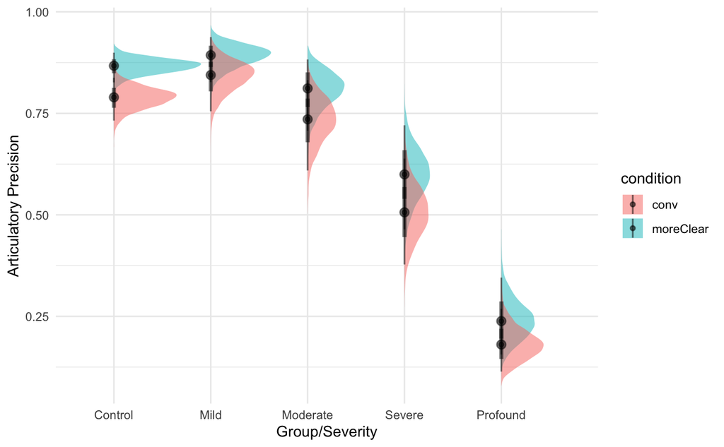

```r
epsilon <- 1e-5
post_AP_data <- modelData %>%
  data_grid(Severity, condition) %>%
  epred_draws(object = condition_AP,
              ndraws = 4000,
              re_formula = NA) %>%
  # Reverse the transformation applied before running the model.
  dplyr::mutate(
    AP = (.epred - epsilon) / (1 - 2 * epsilon),
    # Step 1 & 2: Reverse the offset and scaling
    AP = AP * nrow(modelData) / ((nrow(modelData) - 1) + .5)
  )

post_AP_plot <- post_AP_data %>%
  ggplot() +
  aes(
    y = AP,
    x = Severity,
    group = condition,
    fill = condition
  ) +

  # Density + CrIs
  stat_halfeye(alpha = .5) +

  # Rename axes
  labs(
    y = "Articulatory Precision",
    x = "Group/Severity"
  )
post_AP_plot
```

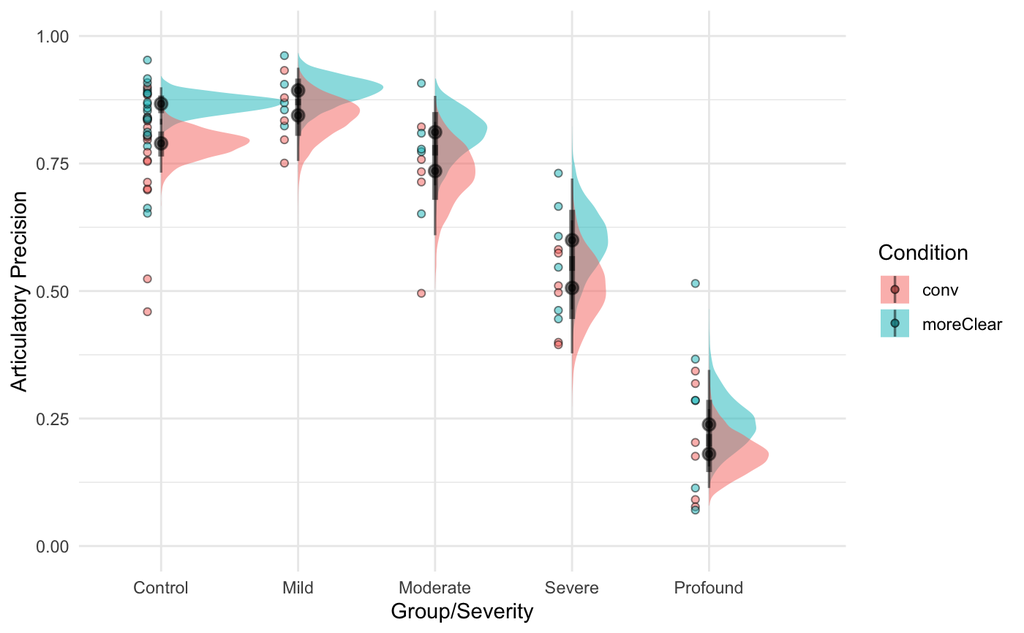

```r
AP_agg <- modelData %>%
  # Reverse the transformation applied before running the model.
  dplyr::mutate(
    AP = (AP - epsilon) / (1 - 2 * epsilon),
    # Step 1 & 2: Reverse the offset and scaling
    AP = AP * nrow(modelData) / ((nrow(modelData) - 1) + .5)
  ) %>%
  group_by(StudyID, Severity, condition) %>%
  dplyr::summarise(AP = mean(AP))
final_AP_plot <- post_AP_plot +
  geom_point(
    data = AP_agg,
    aes(
      y = AP,
    x = Severity,
    group = condition,
    fill = condition),
    pch = 21, alpha = .5,
    position = position_nudge(x = -.1)
  ) +
  coord_cartesian(ylim = c(0,1))  +
  labs(fill = "Condition")
final_AP_plot

ggsave(
  plot = final_AP_plot,
  filename = "Plots/brms_AP.png",
  height = 3,
  width = 5,
  units = "in",
  scale = 1,
  bg = "white"
)
```

## aVSA

Acoustic Vowel Space Area (aVSA) is an acoustic measure of articulatory working space. There are known sex differences when aVSA is measured in Hz. Therefore, we will measure it in Bark to try to reduce the sex effects.

```r
vsaMeasures <- rio::import(file = "../Data/PreppedData/CollatedData/TargetMeasures_vsaMeasures.csv") %>%
  dplyr::filter(condition != "lessClear") %>% # We won't use the less clear condition in this study

  # Here we rename some variables and clean up the factors
  dplyr::mutate(Sex = factor(Sex, levels = c("M", "F")),
                condition = factor(condition, levels = c("conv", "moreClear"))) %>%

  # Now we merge the data with the speakerList, which has information about severity level.
  base::merge(., speakerList %>%
                dplyr::select(StudyID, Severity)) %>%
  dplyr::mutate(
    Severity = factor(
      Severity,
      levels = c("HC", "Mild", "Moderate", "Severe", "Profound"),
      labels = c("Control", "Mild", "Moderate", "Severe", "Profound")
    )
  )

# Lets visualize the outcome measure, aVSA_bark
hist(vsaMeasures$aVSA_bark)

modelData <- vsaMeasures
performance::check_distribution(modelData$aVSA_bark)

# Taking out the trash
rm(vsaMeasures)
```

### Priors

First, we need to figure out the model parameters

```r
brms_aVSA_modelFormula <-
  aVSA_bark ~
  Severity * condition +
  (1 | StudyID) # Here, we only have one aVSA value per speaker and condition

brms::get_prior(
  formula = brms_aVSA_modelFormula,
  data = modelData,
  family = lognormal())
```

Now we can specify weakly informative priors.

```r
# specify priors in log space
priors_aVSA <- c(
  prior(normal(0, 10), class = Intercept),
  prior(normal(0, 10), class = b),
  prior(cauchy(0, 10), class = sd),
  prior(cauchy(0, 10), class = sigma)
)
```

### Building the model

```r
condition_aVSA <- brms::brm(
  formula = brms_aVSA_modelFormula,
  data = modelData,
  family = lognormal(),
  prior = priors_aVSA,
  chains = 4,
  cores = 4,
  iter = 4000,
  warmup = 1000,
  control = list(adapt_delta = 0.95),
  file = "Models/brms_aVSA.rds",
  file_refit = "on_change"
)
```

### Model Summary

```r
summary(condition_aVSA)
tidy(condition_aVSA)
```

### Model Diagnostics

```r
plot(condition_aVSA, variables = "^b_")
pp_check(condition_aVSA, ndraws = 1000)

summary(condition_aVSA)$fixed

plot(conditional_effects(condition_aVSA), ask = FALSE)
```

```r
posterior <- as.matrix(condition_aVSA)
fixed_effects <- posterior %>%
  as.data.frame() %>%
  dplyr::select(starts_with("b_")) %>%
  colnames()

mcmc_areas(posterior,
           pars = fixed_effects,
           # arbitrary threshold for shading probability mass
           prob = 0.95)
```

```r
bayestestR::p_direction(condition_aVSA)
```

### Visualizations

```r
post_aVSA_data <- modelData %>%
  data_grid(Severity, condition) %>%
  epred_draws(object = condition_aVSA, ndraws = 4000, re_formula = NA)

post_aVSA_plot <- post_aVSA_data %>%
  ggplot() +
  aes(y = .epred,
      x = Severity,
      group = condition,
      fill = condition) +

  # Density + CrIs
  stat_halfeye(alpha = .5) +

  # Rename axes
  labs(y = "Acoustic VSA (Bark)", x = "Group/Severity")
post_aVSA_plot

aVSA_agg <- modelData %>%
  group_by(StudyID, Severity, condition) %>%
  dplyr::summarise(.epred = mean(aVSA_bark))

final_aVSA_plot <- post_aVSA_plot +
  geom_point(
    data = aVSA_agg,
    aes(
      y = .epred,
      x = Severity,
      group = condition,
      fill = condition
    ),
    pch = 21,
    alpha = .5,
    position = position_nudge(x = -.1)
  )  +
  labs(fill = "Condition")
final_aVSA_plot

ggsave(
  plot = final_aVSA_plot,
  filename = "Plots/brms_aVSA.png",
  height = 3,
  width = 5,
  units = "in",
  scale = 1,
  bg = "white"
)
```